# Analysis of the types of change present in Apache’s sentry codebase over time

Fabián Santander

7/7/2021

## Sentry data

This is a change analysis between files changed in commits of the project sentry by Apache. See: https://github.com/apache/sentry.

The data generated looks like:

Sentry distilled commits

| filename | change | change_level | level_name | change_start_byte | change_end_byte | line_number | commit_1 | commit_2 | change_content |
| --- | --- | --- | --- | --- | --- | --- | --- | --- | --- |
| HiveAuthzBindingHookBase.java | STATEMENT_INSERT | METHOD | org.apache.sentry.binding.hive.authz.HiveAuthzBindingHookBase.getPrivilegeCache(Set<String>,PrivilegeFactory) | 37839 | 38032 | 875 | f5cad4fb15fa9b3aaf9d691e2df3065860b11353 | 843368fc2aeb154f9cf7b18d191c128644295ce5 | (cacheConstructor != null) |
| HiveAuthzBindingHookBase.java | STATEMENT_INSERT | METHOD | org.apache.sentry.binding.hive.authz.HiveAuthzBindingHookBase.getPrivilegeCache(Set<String>,PrivilegeFactory) | 38117 | 38203 | 882 | f5cad4fb15fa9b3aaf9d691e2df3065860b11353 | 843368fc2aeb154f9cf7b18d191c128644295ce5 | cacheConstructor = Class.forName(privilegeCacheName).getDeclaredConstructor(Set.class); |
| HiveAuthzBindingHookBase.java | STATEMENT_DELETE | METHOD | org.apache.sentry.binding.hive.authz.HiveAuthzBindingHookBase.getPrivilegeCache(Set<String>,PrivilegeFactory) | 38121 | 38222 | 882 | f5cad4fb15fa9b3aaf9d691e2df3065860b11353 | 843368fc2aeb154f9cf7b18d191c128644295ce5 | Constructor<?> cacheConstructor = Class.forName(privilegeCacheName).getDeclaredConstructor(Set.class); |
| HiveAuthzBindingHookBase.java | STATEMENT_DELETE | METHOD | org.apache.sentry.binding.hive.authz.HiveAuthzBindingHookBase.getPrivilegeCache(Set<String>,PrivilegeFactory) | 38399 | 38471 | 887 | f5cad4fb15fa9b3aaf9d691e2df3065860b11353 | 843368fc2aeb154f9cf7b18d191c128644295ce5 | LOG.error(“Exception at creating privilege cache after second try”, ex2); |
| HiveAuthzBindingHookBase.java | STATEMENT_DELETE | METHOD | org.apache.sentry.binding.hive.authz.HiveAuthzBindingHookBase.getPrivilegeCache(Set<String>,PrivilegeFactory) | 37988 | 38503 | 878 | f5cad4fb15fa9b3aaf9d691e2df3065860b11353 | 843368fc2aeb154f9cf7b18d191c128644295ce5 | NoSuchMethodException |
| HiveAuthzBindingHookBase.java | STATEMENT_DELETE | METHOD | org.apache.sentry.binding.hive.authz.HiveAuthzBindingHookBase.getPrivilegeCache(Set<String>,PrivilegeFactory) | 38596 | 38604 | 894 | f5cad4fb15fa9b3aaf9d691e2df3065860b11353 | 843368fc2aeb154f9cf7b18d191c128644295ce5 | ex; |

## Coupled changes

Over the period defined from commit f5cad4fb15fa9b3aaf9d691e2df3065860b11353 to 03236072c606d305fb4a9975fdfa7bbfbdbfb82e whenever a pair of entities (files/methods/classes) were changed in the same commit, the pair and the commit on was recorded.

The cochanges dataset, at the file level, looks like:

Cochanges at file level

| filename.x | change.x | filename.y | change.y | commit |
| --- | --- | --- | --- | --- |
| TestCommonPrivilegeForHive.java | STATEMENT_UPDATE | TestKafkaWildcardPrivilege.java | STATEMENT_UPDATE | 1a2a1ecb237dc2ef3c1e7d0ad11c36c1c374cd89 |
| TestCommonPrivilegeForHive.java | STATEMENT_UPDATE | TestCommonPrivilegeForSolr.java | STATEMENT_UPDATE | 1a2a1ecb237dc2ef3c1e7d0ad11c36c1c374cd89 |
| TestCommonPrivilegeForHive.java | STATEMENT_UPDATE | TestCommonPrivilegeForSqoop.java | STATEMENT_UPDATE | 1a2a1ecb237dc2ef3c1e7d0ad11c36c1c374cd89 |
| TestCommonPrivilegeForHive.java | STATEMENT_UPDATE | PolicyEngine.java | REMOVED_FUNCTIONALITY | 1a2a1ecb237dc2ef3c1e7d0ad11c36c1c374cd89 |
| TestCommonPrivilegeForHive.java | STATEMENT_UPDATE | Privilege.java | REMOVED_FUNCTIONALITY | 1a2a1ecb237dc2ef3c1e7d0ad11c36c1c374cd89 |
| TestCommonPrivilegeForHive.java | STATEMENT_UPDATE | CommonPolicyEngine.java | REMOVED_FUNCTIONALITY | 1a2a1ecb237dc2ef3c1e7d0ad11c36c1c374cd89 |

The cochanges dataset, at the method level, looks like:

Cochanges at method level

| level_name.x | change.x | change_level.x | level_name.y | change.y | change_level.y | commit |
| --- | --- | --- | --- | --- | --- | --- |
| org.apache.sentry.binding.hive.authz.HiveAuthzBinding.authorize(HiveOperation,HiveAuthzPrivileges,Subject,Set<List<DBModelAuthorizable>>,Set<List<DBModelAuthorizable>>) | DOC_UPDATE | METHOD | org.apache.sentry.binding.hive.authz.HiveAuthzBinding | REMOVED_FUNCTIONALITY | CLASS | 1a2a1ecb237dc2ef3c1e7d0ad11c36c1c374cd89 |
| org.apache.sentry.binding.hive.authz.HiveAuthzBinding.authorize(HiveOperation,HiveAuthzPrivileges,Subject,Set<List<DBModelAuthorizable>>,Set<List<DBModelAuthorizable>>) | DOC_UPDATE | METHOD | org.apache.sentry.binding.hive.authz.HiveAuthzBindingHookBase | REMOVED_FUNCTIONALITY | CLASS | 1a2a1ecb237dc2ef3c1e7d0ad11c36c1c374cd89 |
| org.apache.sentry.binding.hive.authz.HiveAuthzBinding.authorize(HiveOperation,HiveAuthzPrivileges,Subject,Set<List<DBModelAuthorizable>>,Set<List<DBModelAuthorizable>>) | DOC_UPDATE | METHOD | org.apache.sentry.binding.metastore.MetastoreAuthzBindingBase.authzConf : HiveAuthzConf | UNCLASSIFIED_CHANGE | FIELD | 1a2a1ecb237dc2ef3c1e7d0ad11c36c1c374cd89 |
| org.apache.sentry.binding.hive.authz.HiveAuthzBinding.authorize(HiveOperation,HiveAuthzPrivileges,Subject,Set<List<DBModelAuthorizable>>,Set<List<DBModelAuthorizable>>) | DOC_UPDATE | METHOD | org.apache.sentry.binding.metastore.MetastoreAuthzBindingBase | REMOVED_FUNCTIONALITY | CLASS | 1a2a1ecb237dc2ef3c1e7d0ad11c36c1c374cd89 |
| org.apache.sentry.binding.hive.authz.HiveAuthzBinding.authorize(HiveOperation,HiveAuthzPrivileges,Subject,Set<List<DBModelAuthorizable>>,Set<List<DBModelAuthorizable>>) | DOC_UPDATE | METHOD | org.apache.sentry.privilege.hive.TestCommonPrivilegeForHive.testUnexpected() | STATEMENT_UPDATE | METHOD | 1a2a1ecb237dc2ef3c1e7d0ad11c36c1c374cd89 |
| org.apache.sentry.binding.hive.authz.HiveAuthzBinding.authorize(HiveOperation,HiveAuthzPrivileges,Subject,Set<List<DBModelAuthorizable>>,Set<List<DBModelAuthorizable>>) | DOC_UPDATE | METHOD | org.apache.sentry.privilege.kafka.TestKafkaWildcardPrivilege.testUnexpected() | STATEMENT_UPDATE | METHOD | 1a2a1ecb237dc2ef3c1e7d0ad11c36c1c374cd89 |

## Summary of data analyzed

Here’s a brief summary of the data analyzed

### Types of changes

The frequencies of the type of changes observed overall are:

Frecuencies of type of changes

| change | n |
| --- | --- |
| STATEMENT_DELETE | 430 |
| STATEMENT_UPDATE | 416 |
| STATEMENT_INSERT | 187 |
| REMOVED_FUNCTIONALITY | 123 |
| STATEMENT_ORDERING_CHANGE | 68 |
| STATEMENT_PARENT_CHANGE | 65 |
| REMOVED_OBJECT_STATE | 59 |
| COMMENT_DELETE | 56 |
| COMMENT_MOVE | 37 |
| CONDITION_EXPRESSION_CHANGE | 24 |
| DECREASING_ACCESSIBILITY_CHANGE | 18 |
| DOC_UPDATE | 17 |
| REMOVED_CLASS | 16 |
| METHOD_RENAMING | 13 |
| ALTERNATIVE_PART_DELETE | 12 |
| UNCLASSIFIED_CHANGE | 12 |
| ADDITIONAL_FUNCTIONALITY | 11 |
| PARAMETER_TYPE_CHANGE | 11 |
| ADDITIONAL_OBJECT_STATE | 9 |
| PARAMETER_DELETE | 9 |
| COMMENT_UPDATE | 8 |
| PARAMETER_INSERT | 8 |
| COMMENT_INSERT | 7 |
| PARAMETER_RENAMING | 7 |
| ALTERNATIVE_PART_INSERT | 4 |
| ATTRIBUTE_RENAMING | 3 |
| ATTRIBUTE_TYPE_CHANGE | 3 |
| DOC_DELETE | 3 |
| RETURN_TYPE_CHANGE | 2 |
| DOC_INSERT | 1 |
| INCREASING_ACCESSIBILITY_CHANGE | 1 |
| PARENT_CLASS_CHANGE | 1 |
| REMOVING_ATTRIBUTE_MODIFIABILITY | 1 |

### Level of changes

The frequencies of the level of the changes made overall are:

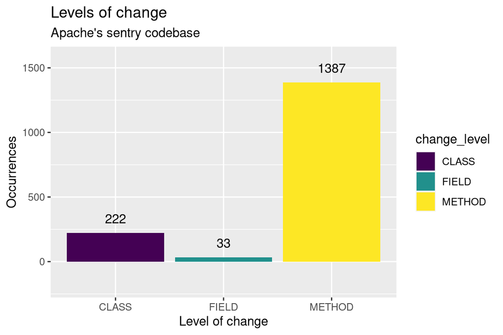

### Changes at the file level

Using the change information that we have available, we counted each change per file over the commits. The following info describes the occurrences of changes per file observed overall:

Descriptive statistics of changes at file level

| mean | sd | p0 | p25 | p50 | p75 | p100 |
| --- | --- | --- | --- | --- | --- | --- |
| 16.098 | 29.334 | 1 | 2 | 4 | 16.75 | 198 |

These can be visualized using a box plot:

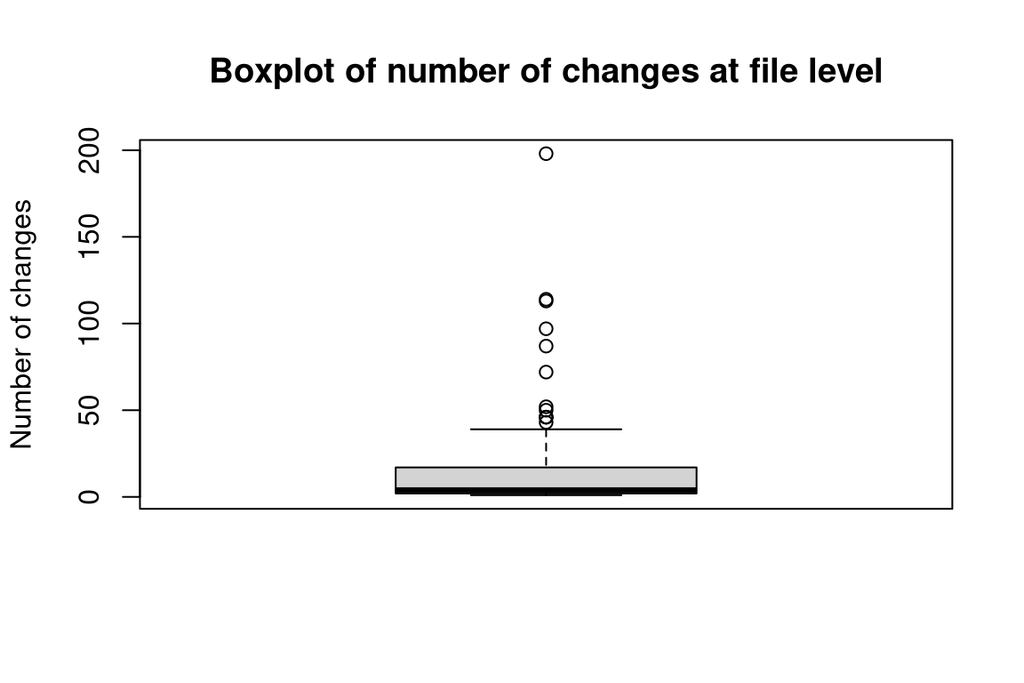

The outliers being:

Table of outliers

| filename | n |
| --- | --- |
| TestOwnerPrivileges.java | 198 |
| TSentryExportMappingDataRequest.java | 114 |
| TestKafkaAction.java | 113 |
| TestAuthorizingObjectStore.java | 97 |
| TestHDFSIntegrationEnd2End.java | 87 |
| TestDelegateSentryStore.java | 72 |
| TestPrivilegesAtFunctionScope.java | 52 |
| HiveAuthzBindingHookBase.java | 50 |
| QueryDocAuthorizationComponent.java | 46 |
| TestHDFSIntegrationBase.java | 46 |
| TSentryPrivilegesResponse.java | 46 |
| MetastoreAuthzBindingBase.java | 43 |

### Changes at method/class/access level

Using the method level information available, we counted the changes recorded per method. The following info describes the occurrences of changes per method/class/access observed overall:

Descriptive statistics of changes at method level

| mean | sd | p0 | p25 | p50 | p75 | p100 |
| --- | --- | --- | --- | --- | --- | --- |
| 5.585 | 10.202 | 1 | 1 | 2 | 5.75 | 96 |

These can be visualized using a box plot:

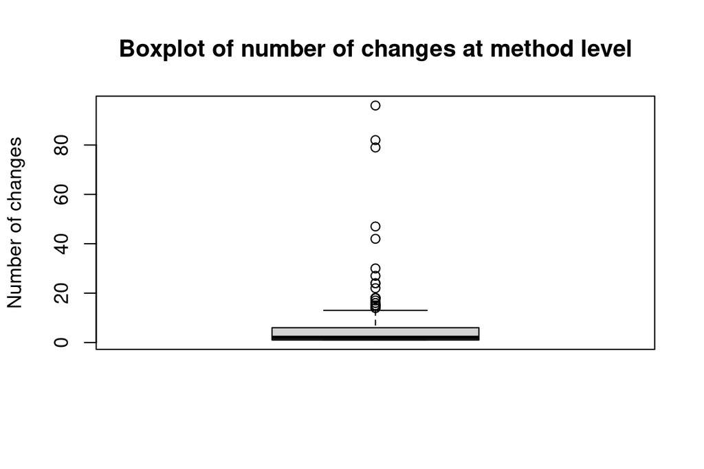

The outliers being:

Table of outliers

| level_name | n |
| --- | --- |
| org.apache.sentry.tests.e2e.metastore.TestAuthorizingObjectStore.testPrivilegesForPartialAccess() | 96 |
| org.apache.sentry.core.model.kafka.TestKafkaAction.testImpliesAction() | 82 |
| org.apache.sentry.tests.e2e.hdfs.TestHDFSIntegrationEnd2End.testEnd2End() | 79 |
| org.apache.sentry.tests.e2e.dbprovider.TestOwnerPrivileges.testAuthorizeAlterTableSetOwner() | 47 |
| org.apache.sentry.provider.db.generic.service.persistent.TestDelegateSentryStore.testGetGroupsByRoleNames() | 42 |
| org.apache.sentry.provider.db.generic.service.persistent.TestDelegateSentryStore.testAddDeleteRoleToGroups() | 30 |
| org.apache.sentry.binding.hive.HiveAuthzBindingHook.preAnalyze(HiveSemanticAnalyzerHookContext,ASTNode) | 27 |
| org.apache.sentry.provider.db.log.appender.TestRollingFileWithoutDeleteAppender.testFileNamePattern() | 24 |
| org.apache.sentry.tests.e2e.dbprovider.TestColumnEndToEnd.testCrossDbTableOperations() | 24 |
| org.apache.sentry.binding.hive.SentryIniPolicyFileFormatter.write(String,Map<String, Map<String, Set<String>>>) | 22 |
| org.apache.sentry.api.service.thrift.TSentryPrivilegesResponse.TSentryPrivilegesResponseStandardScheme.read(org.apache.thrift.protocol.TProtocol,TSentryPrivilegesResponse) | 18 |
| org.apache.sentry.api.service.thrift.TSentryPrivilegesResponse.TSentryPrivilegesResponseTupleScheme.read(org.apache.thrift.protocol.TProtocol,TSentryPrivilegesResponse) | 18 |
| org.apache.sentry.binding.hive.TestSentryIniPolicyFileFormatter.testImportExport() | 18 |
| org.apache.sentry.service.thrift.SentryKerberosContext.run() | 18 |
| org.apache.sentry.tests.e2e.dbprovider.TestOwnerPrivileges.testAlterTable() | 18 |
| org.apache.sentry.tests.e2e.dbprovider.TestOwnerPrivileges.testAuthorizeAlterDatabaseSetOwner() | 18 |
| org.apache.sentry.tests.e2e.hive.TestPrivilegesAtFunctionScope.testCreateDropPermUdf() | 18 |
| org.apache.sentry.tests.e2e.hive.TestPrivilegesAtFunctionScope.testCreateDropTempUdf() | 17 |
| org.apache.sentry.binding.hive.authz.HiveAuthzBindingHookBase.authorizeWithHiveBindings(HiveSemanticAnalyzerHookContext,HiveAuthzPrivileges,HiveOperation) | 16 |
| org.apache.sentry.service.thrift.GSSCallback.allowConnect(String) | 16 |
| org.apache.sentry.api.service.thrift.TSentryExportMappingDataRequest | 15 |
| org.apache.sentry.api.service.thrift.TSentryExportMappingDataRequest.TSentryExportMappingDataRequestStandardScheme.read(org.apache.thrift.protocol.TProtocol,TSentryExportMappingDataRequest) | 15 |
| org.apache.sentry.binding.hive.authz.HiveAuthzBindingHookBase.getPrivilegeCache(Set<String>,PrivilegeFactory) | 15 |
| org.apache.sentry.binding.metastore.MetastoreAuthzBindingBase.getPrivilegeCache(Set<String>,PrivilegeFactory) | 15 |
| org.apache.sentry.core.common.utils.KeyValue.KeyValue(String) | 15 |
| org.apache.sentry.core.model.kafka.TestKafkaAction.testGetActionsByCode() | 15 |
| org.apache.sentry.tests.e2e.dbprovider.TestOwnerPrivilegesWithGrantOption.testAuthorizeAlterTableSetOwnerByOwner() | 15 |
| org.apache.solr.handler.component.QueryDocAuthorizationComponent | 15 |
| org.apache.sentry.core.model.kafka.TestKafkaAction.testGetActionByName() | 14 |
| org.apache.sentry.provider.common.ResourceAuthorizationProvider.doHasAccess(Subject,List<? extends Authorizable>,Set<? extends Action>,boolean,ActiveRoleSet) | 14 |
| org.apache.sentry.tests.e2e.hdfs.TestHDFSIntegrationBase.verifyOnAllSubDirsHelper(Path,FsAction,String,boolean,boolean,int) | 14 |

### Coupled changes

Here we used the info we got from the coupled changes analysis.

#### File level

Using the cochange information available, we counted the changes recorded per file. The following info describes the occurrences of changes per file observed overall:

Descriptive statistics of cochanges at file level

| mean | sd | p0 | p25 | p50 | p75 | p100 |
| --- | --- | --- | --- | --- | --- | --- |
| 4.56 | 3.72 | 1 | 2 | 2 | 9 | 9 |

These can be visualized using a box plot:

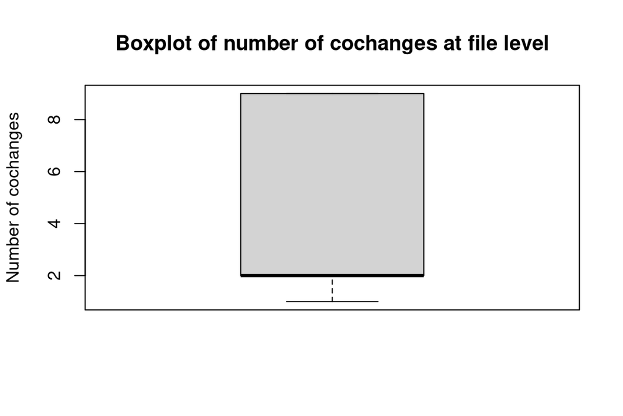

The outliers being:

Table of outliers

| filename.x | n |
| --- | --- |

#### Method level

Using the cochange information available, we counted the changes recorded per method. The following info describes the occurrences of changes per method observed overall:

Descriptive statistics of cochanges at method level

| mean | sd | p0 | p25 | p50 | p75 | p100 |
| --- | --- | --- | --- | --- | --- | --- |
| 7.898 | 4.854 | 1 | 4 | 7 | 9 | 16 |

These can be visualized using a box plot:

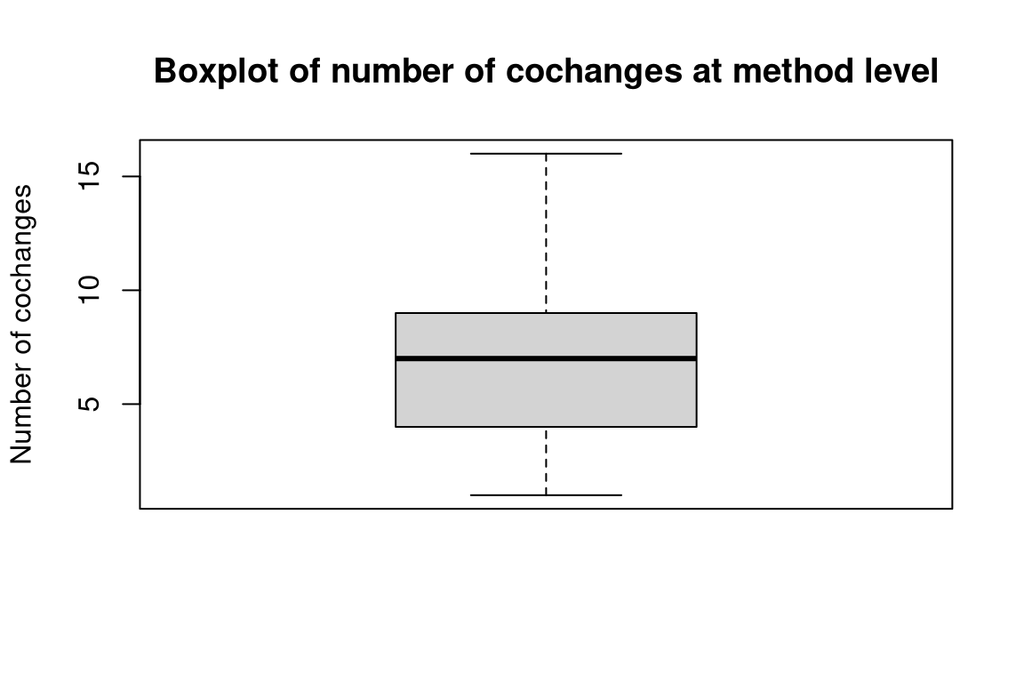

The outliers being:

Table of outliers

| level_name.x | n |
| --- | --- |